# Who falls for Misinformation?

Sanjay Chhetri

11/28/2021

# Data Source

I obtained the dataset from a repository publicly shared by the authors of a published article. [Link to the article](https://doi.org/10.1016/j.dib.2020.106031) For this article, the authors used the dataset to run a Confirmatory Factor Analysis. The sample is entirely from Africa, by design. The dataset represents a total of 21 African countries. I used the dataset to run a multiple regression to find out what factors predict the subscription of COVID-related misinformation.

```r
raw_data <- read_csv("covid_africa_data_untouched.csv")
head(raw_data)
```

```
## # A tibble: 6 x 35
##   Timestamp          Gender `Age class`  `Highest level of ed~ `Country of Orig~
##   <chr>              <chr>  <chr>        <chr>                 <chr>
## 1 2020/03/31 1:18:4~ Male   35 - 39 yea~ Post Graduate level   Nigeria
## 2 2020/03/31 1:26:2~ Male   40 - 49 yea~ Post Graduate level   Nigeria
## 3 2020/03/31 1:34:2~ Male   35 - 39 yea~ Post Graduate level   Nigeria
## 4 2020/03/31 1:34:3~ Female 25 - 29 yea~ Post Graduate level   Nigeria
## 5 2020/03/31 1:35:1~ Male   30 - 34 yea~ Tertiary education    Nigeria
## 6 2020/03/31 1:35:5~ Male   35 - 39 yea~ Post Graduate level   Nigeria
## # ... with 30 more variables: Region of your country <chr>,
## #   Religion faith/belief <chr>,
## #   Do you know anyone/have seen anyone infected with the novel COVID19? <chr>,
## #   Source of information about Coronavirus (COVID19). Please tick as many as applicable. <chr>,
## #   If you will love to receive a copy of the published work, please include your email address below. <chr>,
## #   Coronavirus (COVID19) is a man-made virus to reduce the human population <chr>,
## #   China made the novel Coronavirus (COVID19) in order to become the global power <chr>, ...
```

```r
glimpse(raw_data)
```

```
## Rows: 563
## Columns: 35
## $ Timestamp                                                                                                                  <chr> ~
## $ Gender                                                                                                                     <chr> ~
## $ `Age class`                                                                                                                <chr> ~
## $ `Highest level of education`                                                                                               <chr> ~
## $ `Country of Origin`                                                                                                        <chr> ~
## $ `Region of your country`                                                                                                   <chr> ~
## $ `Religion faith/belief`                                                                                                    <chr> ~
## $ `Do you know anyone/have seen anyone infected with the novel COVID19?`                                                     <chr> ~
## $ `Source of information about Coronavirus (COVID19). Please tick as many as applicable.`                                    <chr> ~
## $ `If you will love to receive a copy of the published work, please include your email address below.`                       <chr> ~
## $ `Coronavirus (COVID19) is a man-made virus to reduce the human population`                                                 <chr> ~
## $ `China made the novel Coronavirus (COVID19) in order to become the global power`                                           <chr> ~
## $ `African Blood compositions resist COVID19.`                                                                               <chr> ~
```

[output cut: 22 more lines]

```r
renamed_data <- raw_data %>%
  rename_with(.cols = 11:23, .fn = ~ paste0("q", 1:13)) %>%
  rename(familiarity = contains("Do you know anyone"))
names(renamed_data[,c(8,11:23)])
```

```
##  [1] "familiarity" "q1"          "q2"          "q3"          "q4"
##  [6] "q5"          "q6"          "q7"          "q8"          "q9"
## [11] "q10"         "q11"         "q12"         "q13"
```

The dataset was in csv file. After reading it in R, I subset it to include only the variables needed for my analysis. Two variables pertaining to the source of covid information and religious orientation could be included in the model but I opted not to use them. FOr the former, the questionnaire gave multiple choices on COVID information source and most participants chose various options. For religion, vast majority chose Christianity and Islam, with only a handful with ‘don’t want to tell’/‘other’/‘neutral’. It would basically be comparing one religion vs another.

# Reshaping the dataset

Here I select only the variables that are of use for my analysis.

```r
df1 <- renamed_data %>% mutate(gender = factor(Gender),
         age_group = factor(`Age class`),
         education = factor(`Highest level of education`),
         familiarity = factor(familiarity)) %>%
  select(gender, age_group, education,  familiarity, q1:q13)
```

# Data Wrangling

Here I recategorieze some variables to make them more readable.

```r
table(df1$age_group)
```

```
##
##      18 - 24 years      25 - 29 years      30 - 34 years      35 - 39 years
##                122                118                100                 75
##      40 - 49 years      50 - 59 years      60 - 69 years 70 years and above
##                 86                 46                  9                  4
## Less than 18 years
##                  3
```

```r
# collapsing age class varible to three categories
levels(df1$age_group) <- list("Youths" = c("Less than 18 years", "18 - 24 years", "25 - 29 years"),
                        "Adults" = c("30 - 34 years", "35 - 39 years", "40 - 49 years"),
                        "Elderly" = c("50 - 59 years", "60 - 69 years", "70 years and above"))
sum(is.na(df1$age_group)) #checking missing values
```

```
## [1] 0
```

```r
table(df1$education)
```

```
##
##                      No formal education
##                                        2
##                      Post Graduate level
##                                      307
##                  Primary/Basic education
##                                        2
## Secondary/high school/form 4/5 education
##                                       33
##                       Tertiary education
##                                      219
```

```r
levels(df1$education) <- list("Post_grad" =  "Post Graduate level",
                              "College" = "Tertiary education",
                              "No_college" = c("No formal education", "Primary/Basic education", "Secondary/high school/form 4/5 education"))

table(df1$education)
```

```
##
##  Post_grad    College No_college
##        307        219         37
```

```r
sum(is.na(renamed_data$`Highest level of education`)) #checking na in raw data
```

```
## [1] 0
```

```r
sum(is.na(df1$education)) #checking NA's after manipulation
```

```
## [1] 0
```

Collapsing various age groups into three general groups made sense to see the age effect with better clarity. Collapsing various education levels into three groups (post graduate level, college educated, and no college) facilitated a better comparison.

# More Data Manipulation

Here, I first convert the likert scale texts into their numerical equivalents as suggested by the data source. Then I aggregate the misinformation related columns taking average.

```r
df1[df1 == "Strongly Disagree"] <- "0"
df1[df1 == "Disagree"] <- "0"
df1[df1 == "Neutral"] <- "1"
df1[df1=="Agree"] <- "4"
df1[df1=="Strongly Agree"] <- "4"
head(df1)
```

```
## # A tibble: 6 x 17
##   gender age_group education familiarity q1    q2    q3    q4    q5    q6
##   <fct>  <fct>     <fct>     <fct>       <chr> <chr> <chr> <chr> <chr> <chr>
## 1 Male   Adults    Post_grad No          0     1     1     4     4     0
## 2 Male   Adults    Post_grad No          4     1     1     1     4     1
## 3 Male   Adults    Post_grad No          0     0     0     1     0     0
## 4 Female Youths    Post_grad No          1     1     0     0     0     1
## 5 Male   Adults    College   No          1     1     1     1     1     1
## 6 Male   Adults    Post_grad No          1     1     4     4     4     1
## # ... with 7 more variables: q7 <chr>, q8 <chr>, q9 <chr>, q10 <chr>,
## #   q11 <chr>, q12 <chr>, q13 <chr>
```

```r
class(df1$q1)
```

```
## [1] "character"
```

```r
df1[, 5:17] <- lapply(df1[, 5:17], as.numeric)
class(df1$q1)
```

```
## [1] "numeric"
```

```r
head(df1)
```

```
## # A tibble: 6 x 17
##   gender age_group education familiarity    q1    q2    q3    q4    q5    q6
##   <fct>  <fct>     <fct>     <fct>       <dbl> <dbl> <dbl> <dbl> <dbl> <dbl>
## 1 Male   Adults    Post_grad No              0     1     1     4     4     0
## 2 Male   Adults    Post_grad No              4     1     1     1     4     1
## 3 Male   Adults    Post_grad No              0     0     0     1     0     0
## 4 Female Youths    Post_grad No              1     1     0     0     0     1
## 5 Male   Adults    College   No              1     1     1     1     1     1
## 6 Male   Adults    Post_grad No              1     1     4     4     4     1
## # ... with 7 more variables: q7 <dbl>, q8 <dbl>, q9 <dbl>, q10 <dbl>,
## #   q11 <dbl>, q12 <dbl>, q13 <dbl>
```

```r
df1$q <- rowMeans(subset(df1, select = q1:q13), na.rm = T)
head(df1)
```

```
## # A tibble: 6 x 18
##   gender age_group education familiarity    q1    q2    q3    q4    q5    q6
##   <fct>  <fct>     <fct>     <fct>       <dbl> <dbl> <dbl> <dbl> <dbl> <dbl>
## 1 Male   Adults    Post_grad No              0     1     1     4     4     0
## 2 Male   Adults    Post_grad No              4     1     1     1     4     1
## 3 Male   Adults    Post_grad No              0     0     0     1     0     0
## 4 Female Youths    Post_grad No              1     1     0     0     0     1
## 5 Male   Adults    College   No              1     1     1     1     1     1
## 6 Male   Adults    Post_grad No              1     1     4     4     4     1
## # ... with 8 more variables: q7 <dbl>, q8 <dbl>, q9 <dbl>, q10 <dbl>,
## #   q11 <dbl>, q12 <dbl>, q13 <dbl>, q <dbl>
```

```r
df <- df1 %>% select(gender, age_group, education, familiarity, q )
head(df)
```

```
## # A tibble: 6 x 5
##   gender age_group education familiarity     q
##   <fct>  <fct>     <fct>     <fct>       <dbl>
## 1 Male   Adults    Post_grad No          1.46
## 2 Male   Adults    Post_grad No          2.08
## 3 Male   Adults    Post_grad No          0.462
## 4 Female Youths    Post_grad No          1.62
## 5 Male   Adults    College   No          1
## 6 Male   Adults    Post_grad No          2.15
```

Here, q is the outcome variable and represents the extent to which one is misinformed about COVID (subscribes to COVID related misinformation)

##What’s the distribution of misinformation score (q)?

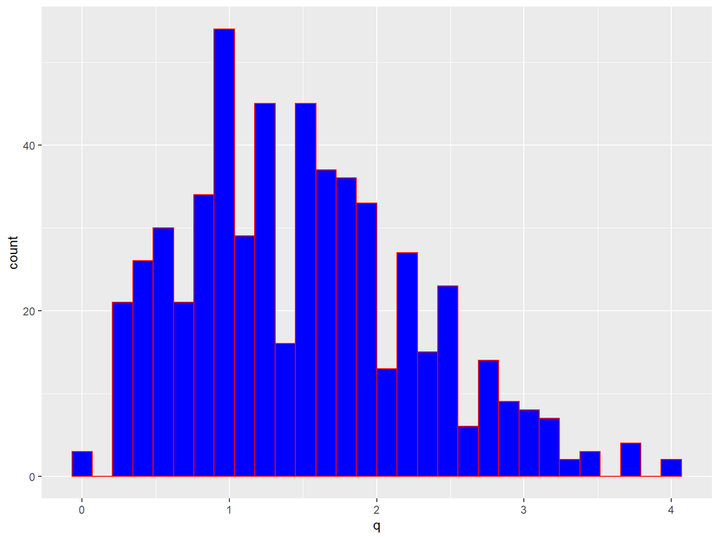

# Regression

```r
fit <- lm(q~gender+age_group+education+familiarity, data = df)
summary(fit)
```

```
##
## Call:
## lm(formula = q ~ gender + age_group + education + familiarity,
##     data = df)
##
## Residuals:
##      Min       1Q   Median       3Q      Max
## -1.45337 -0.60202 -0.07946  0.47185  2.53592
##
## Coefficients:
##                      Estimate Std. Error t value Pr(>|t|)
## (Intercept)          1.449079   0.079250  18.285  < 2e-16 ***
## genderMale          -0.009089   0.069888  -0.130    0.897
## age_groupAdults     -0.051024   0.073807  -0.691    0.490
## age_groupElderly     0.013376   0.120474   0.111    0.912
## educationCollege     0.044380   0.073319   0.605    0.545
## educationNo_college  0.653128   0.138735   4.708 3.17e-06 ***
## familiarityYes       0.075115   0.084150   0.893    0.372
## ---
## Signif. codes:  0 '***' 0.001 '**' 0.01 '*' 0.05 '.' 0.1 ' ' 1
##
## Residual standard error: 0.7687 on 556 degrees of freedom
## Multiple R-squared:  0.0437, Adjusted R-squared:  0.03339
## F-statistic: 4.235 on 6 and 556 DF,  p-value: 0.0003509
```

The regression model with ‘q’ as the outcome and gender, age_group, education, and familiarity as explanatory variables is significant, F(6, 556) = 4.235, p<0.001. The model explains 4.37% of the variance in the misinformation index (outcome, denoted by q), with adjusted R squared at 0.034. Education is the only variable that significantly predicts the misinformation index. With no significant difference between college and post-grad educated people. People with no college significantly differed in misinformation index. On average, people with no colleged measured 0.65 points higher in misinformation index compared to to the post graduated educated group.

##Is there Any interaction effect?

```r
#check a suspect interaction
model1 <- lm(q~gender+age_group+education+familiarity+familiarity:education, data = df)
summary(model1)
```

```
##
## Call:
## lm(formula = q ~ gender + age_group + education + familiarity +
##     familiarity:education, data = df)
##
## Residuals:
##      Min       1Q   Median       3Q      Max
## -1.46139 -0.59211 -0.06798  0.47022  2.54741
##
## Coefficients:
##                                     Estimate Std. Error t value Pr(>|t|)
## (Intercept)                         1.448188   0.080618  17.963  < 2e-16 ***
## genderMale                         -0.008945   0.070007  -0.128    0.898
## age_groupAdults                    -0.043713   0.074194  -0.589    0.556
## age_groupElderly                    0.022145   0.120414   0.184    0.854
## educationCollege                    0.047345   0.080232   0.590    0.555
## educationNo_college                 0.595787   0.143010   4.166 3.59e-05 ***
## familiarityYes                      0.057065   0.100233   0.569    0.569
## educationCollege:familiarityYes    -0.022818   0.187793  -0.122    0.903
## educationNo_college:familiarityYes  1.057279   0.567466   1.863    0.063 .
## ---
## Signif. codes:  0 '***' 0.001 '**' 0.01 '*' 0.05 '.' 0.1 ' ' 1
##
## Residual standard error: 0.7676 on 554 degrees of freedom
## Multiple R-squared:  0.0498, Adjusted R-squared:  0.03608
## F-statistic:  3.63 on 8 and 554 DF,  p-value: 0.0003951
```

Looks like there is not.

# Some visualizations

Let the plots speak!

```r
require(gridExtra)
```

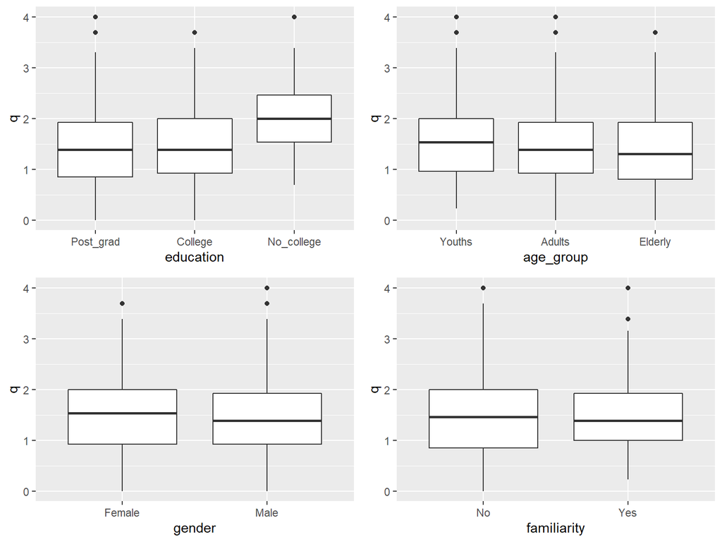

```r
p1 <- df %>% ggplot(aes(x=education, y=q))+
 geom_boxplot()
p2 <- df %>% ggplot(aes(age_group, y=q))+geom_boxplot()
p3 <- ggplot(df, aes(gender, q,))+geom_boxplot()
p4 <- ggplot(df, aes(familiarity, q))+geom_boxplot()
grid.arrange(p1, p2, p3, p4, ncol =2)
```

##Figment of Imagination

If we had a continuous/descrete predictor such as age, visualization would be more fun

```r
df2 <- df
age_img <- sample(18:70, size = 563, replace = TRUE)
df2$age <- age_img
df2 <- df2 %>% relocate(age, .before = q)
head(df2)
```

```
## # A tibble: 6 x 6
##   gender age_group education familiarity   age     q
##   <fct>  <fct>     <fct>     <fct>       <int> <dbl>
## 1 Male   Adults    Post_grad No             55 1.46
## 2 Male   Adults    Post_grad No             51 2.08
## 3 Male   Adults    Post_grad No             44 0.462
## 4 Female Youths    Post_grad No             33 1.62
## 5 Male   Adults    College   No             39 1
## 6 Male   Adults    Post_grad No             44 2.15
```

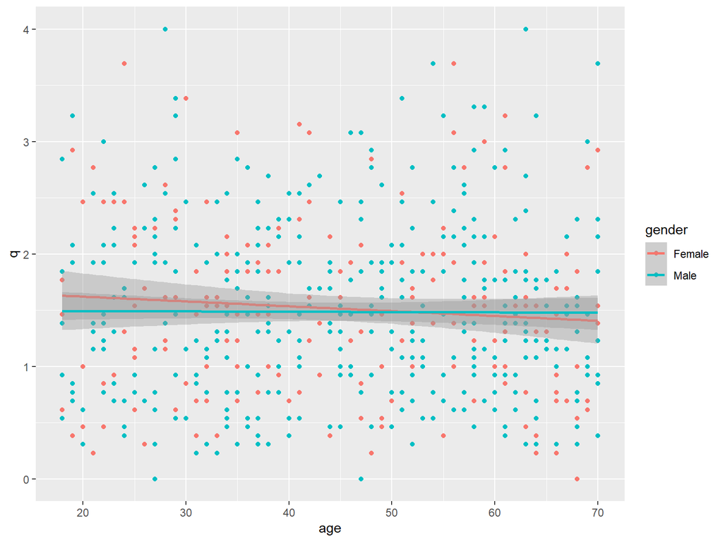

```r
df2 %>% ggplot(aes(x=age, y = q, color = gender))+
  geom_point()+geom_smooth(method = "lm")
```